# Linear Regression-1

MGinorio

11/3/2021

```r
library(tidyverse)
library(moderndive)
library(skimr)
library(ISLR)
library(tinytex)
```

## Dataset

**evals dataset**

Researchers at the University of Texas in Austin, Texas (UT Austin) tried to answer the following research question: what factors explain differences in instructor teaching evaluation scores?

To this end, they collected instructor and course information on 463 courses. A full description of the study can be found at openintro.org.

```r
glimpse(evals)
```

```
## Rows: 463
## Columns: 14
## $ ID           <int> 1, 2, 3, 4, 5, 6, 7, 8, 9, 10, 11, 12, 13, 14, 15, 16, 17~
## $ prof_ID      <int> 1, 1, 1, 1, 2, 2, 2, 3, 3, 4, 4, 4, 4, 4, 4, 4, 4, 5, 5, ~
## $ score        <dbl> 4.7, 4.1, 3.9, 4.8, 4.6, 4.3, 2.8, 4.1, 3.4, 4.5, 3.8, 4.~
## $ age          <int> 36, 36, 36, 36, 59, 59, 59, 51, 51, 40, 40, 40, 40, 40, 4~
## $ bty_avg      <dbl> 5.000, 5.000, 5.000, 5.000, 3.000, 3.000, 3.000, 3.333, 3~
## $ gender       <fct> female, female, female, female, male, male, male, male, m~
## $ ethnicity    <fct> minority, minority, minority, minority, not minority, not~
## $ language     <fct> english, english, english, english, english, english, eng~
## $ rank         <fct> tenure track, tenure track, tenure track, tenure track, t~
## $ pic_outfit   <fct> not formal, not formal, not formal, not formal, not forma~
## $ pic_color    <fct> color, color, color, color, color, color, color, color, c~
## $ cls_did_eval <int> 24, 86, 76, 77, 17, 35, 39, 55, 111, 40, 24, 24, 17, 14, ~
## $ cls_students <int> 43, 125, 125, 123, 20, 40, 44, 55, 195, 46, 27, 25, 20, 2~
## $ cls_level    <fct> upper, upper, upper, upper, upper, upper, upper, upper, u~
```

### Question

Can we explain differences in teaching evaluation score based on various teacher attributes?

### Variables

$y:$ Average teaching $score$ based on students evaluations

$\vec{x}$ Attributes like gender, ethnicity, bty_avg

Investigate correlation between this variables

- ID
- Score
- Age
- Gender
- Rank
- Cls_students

```r
evals_disc12 <- evals %>%
  select(ID, score, gender, age, rank, cls_students, ethnicity)

evals_disc12
```

```
## # A tibble: 463 x 7
##       ID score gender   age rank         cls_students ethnicity
##    <int> <dbl> <fct>  <int> <fct>               <int> <fct>
##  1     1   4.7 female    36 tenure track           43 minority
##  2     2   4.1 female    36 tenure track          125 minority
##  3     3   3.9 female    36 tenure track          125 minority
##  4     4   4.8 female    36 tenure track          123 minority
##  5     5   4.6 male      59 tenured                20 not minority
##  6     6   4.3 male      59 tenured                40 not minority
##  7     7   2.8 male      59 tenured                44 not minority
##  8     8   4.1 male      51 tenured                55 not minority
##  9     9   3.4 male      51 tenured               195 not minority
## 10    10   4.5 female    40 tenured                46 not minority
## # ... with 453 more rows
```

### EDA

Understanding Each Variable

We will perform an exploratory analysis of the selected variables before any formal modeling

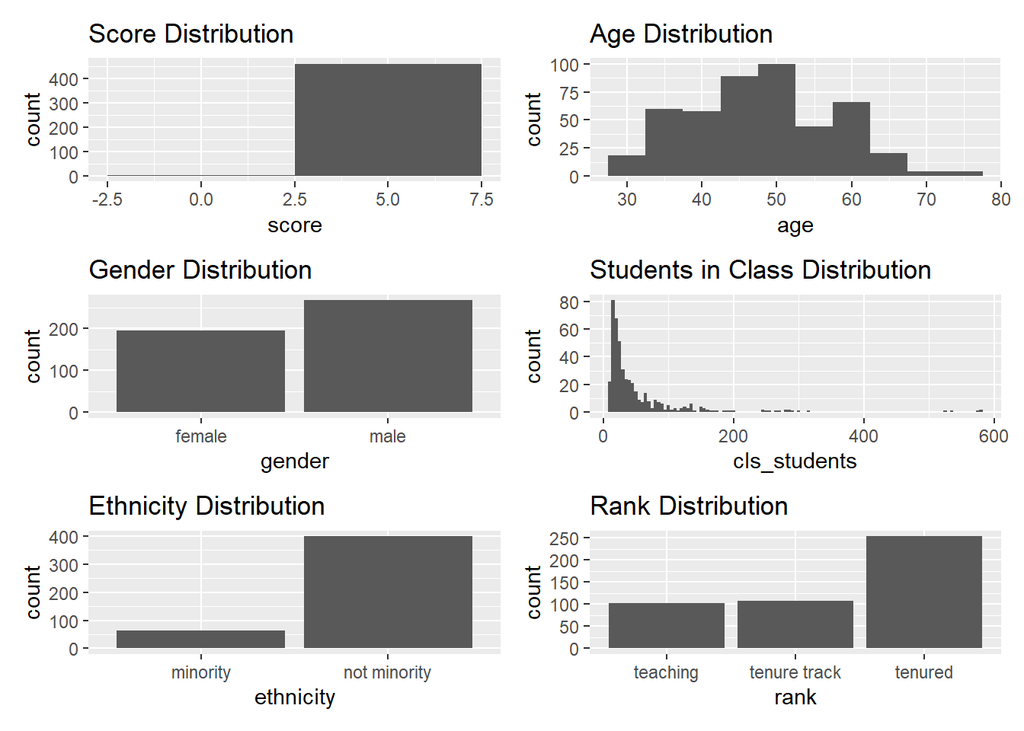

### Statistics

```r
evals_disc12 %>%
  select(score, gender, age, rank, cls_students, ethnicity) %>% skim()
```

Data summary

| Name | Piped data |
| --- | --- |
| Number of rows | 463 |
| Number of columns | 6 |
| _______________________ |  |
| Column type frequency: |  |
| factor | 3 |
| numeric | 3 |
| ________________________ |  |
| Group variables | None |

**Variable type: factor**

| skim_variable | n_missing | complete_rate | ordered | n_unique | top_counts |
| --- | --- | --- | --- | --- | --- |
| gender | 0 | 1 | FALSE | 2 | mal: 268, fem: 195 |
| rank | 0 | 1 | FALSE | 3 | ten: 253, ten: 108, tea: 102 |
| ethnicity | 0 | 1 | FALSE | 2 | not: 399, min: 64 |

**Variable type: numeric**

| skim_variable | n_missing | complete_rate | mean | sd | p0 | p25 | p50 | p75 | p100 | hist |
| --- | --- | --- | --- | --- | --- | --- | --- | --- | --- | --- |
| score | 0 | 1 | 4.17 | 0.54 | 2.3 | 3.8 | 4.3 | 4.6 | 5 | ▁▁▅▇▇ |
| age | 0 | 1 | 48.37 | 9.80 | 29.0 | 42.0 | 48.0 | 57.0 | 73 | ▅▆▇▆▁ |
| cls_students | 0 | 1 | 55.18 | 75.07 | 8.0 | 19.0 | 29.0 | 60.0 | 581 | ▇▁▁▁▁ |

**Visual Relationship**

Following the scatterplots indicate the relationship of the independent variables witht the dependent variable (score)

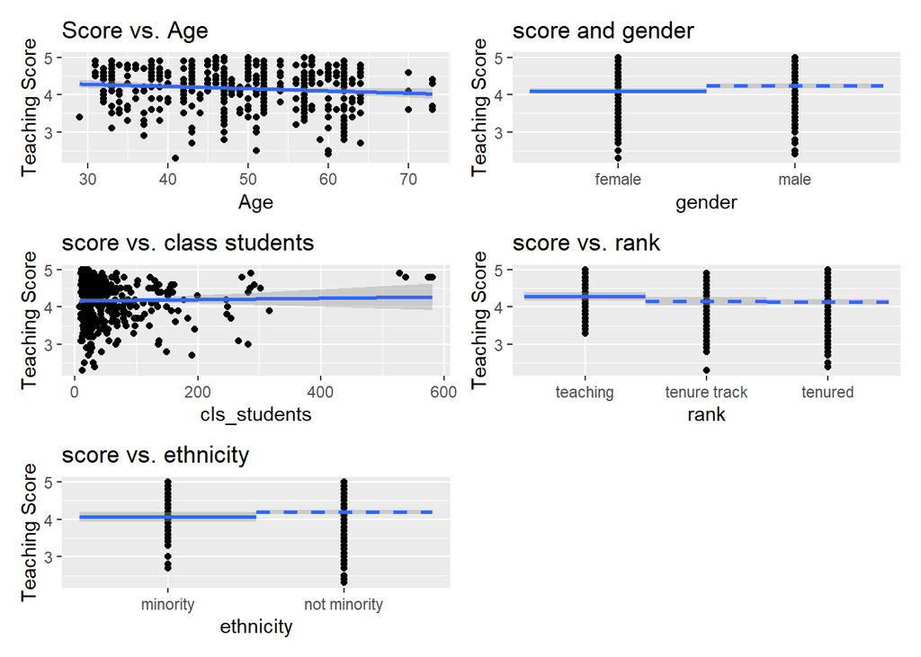

CATEGORICAL VARS -

When using a categorical predictor variable, the intercept corresponds to the mean for the baseline group, while coefficients for the non-baseline groups are offsets from this baseline. Thus in the visualization the baseline for comparison group’s median is marked with a solid line, whereas all offset groups’ medians are marked with dashed lines

### Dichotomous Var

We can see in the scatter plot above that the amount of students in the classrooms goes from 0-600. In which the vast majority is distributed between 0-200. Having that in mind I will create a Dichotomous variable for num_students in a classroom less than 100 for “Y” and more than 100 to “N”

```r
evals_disc12$num_students <- ifelse(evals_disc12$cls_students <= 100, "Y", "N")
evals_disc12$num_students_n <- ifelse(evals_disc12$num_students == "Y", 1,0)
```

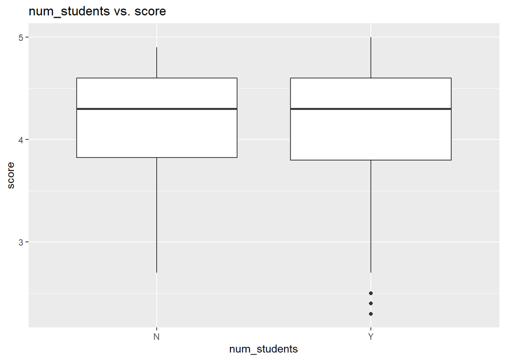

```r
evals_disc12 %>%
  ggplot(aes(x = num_students, y = score)) +
  geom_boxplot() +
  labs(title = "num_students vs. score")
```

num_students boxplot indicates a slight difference in score when teacher has more than 100 students

### Create Model

**Score Model**

```
##
## Call:
## lm(formula = score ~ gender + age + rank + cls_students + ethnicity,
##     data = evals_disc12)
##
## Residuals:
##     Min      1Q  Median      3Q     Max
## -1.7769 -0.3589  0.0773  0.4233  1.0083
##
## Coefficients:
##                         Estimate Std. Error t value Pr(>|t|)
## (Intercept)            4.649e+00  1.759e-01  26.429  < 2e-16 ***
## gendermale             1.942e-01  5.328e-02   3.645 0.000298 ***
## age                   -1.098e-02  3.111e-03  -3.531 0.000457 ***
## ranktenure track      -2.165e-01  8.246e-02  -2.626 0.008941 **
## ranktenured           -1.659e-01  6.395e-02  -2.594 0.009794 **
## cls_students           8.954e-05  3.380e-04   0.265 0.791216
## ethnicitynot minority  9.342e-02  7.318e-02   1.277 0.202406
## ---
## Signif. codes:  0 '***' 0.001 '**' 0.01 '*' 0.05 '.' 0.1 ' ' 1
##
## Residual standard error: 0.5299 on 456 degrees of freedom
## Multiple R-squared:  0.06308,    Adjusted R-squared:  0.05076
## F-statistic: 5.117 on 6 and 456 DF,  p-value: 4.21e-05
```

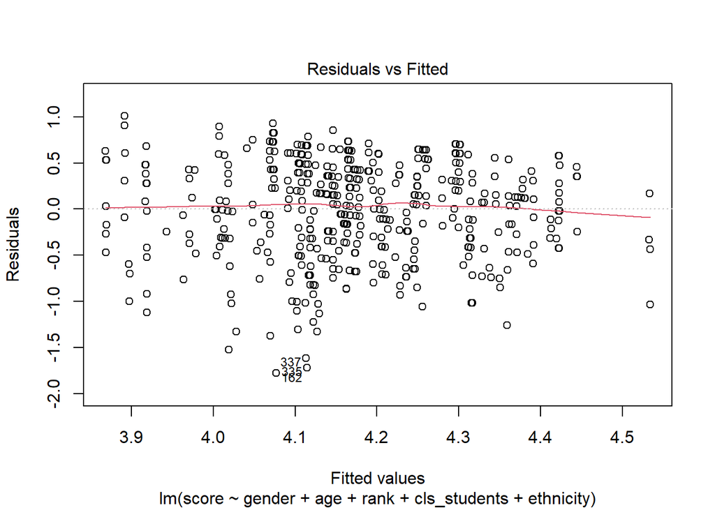

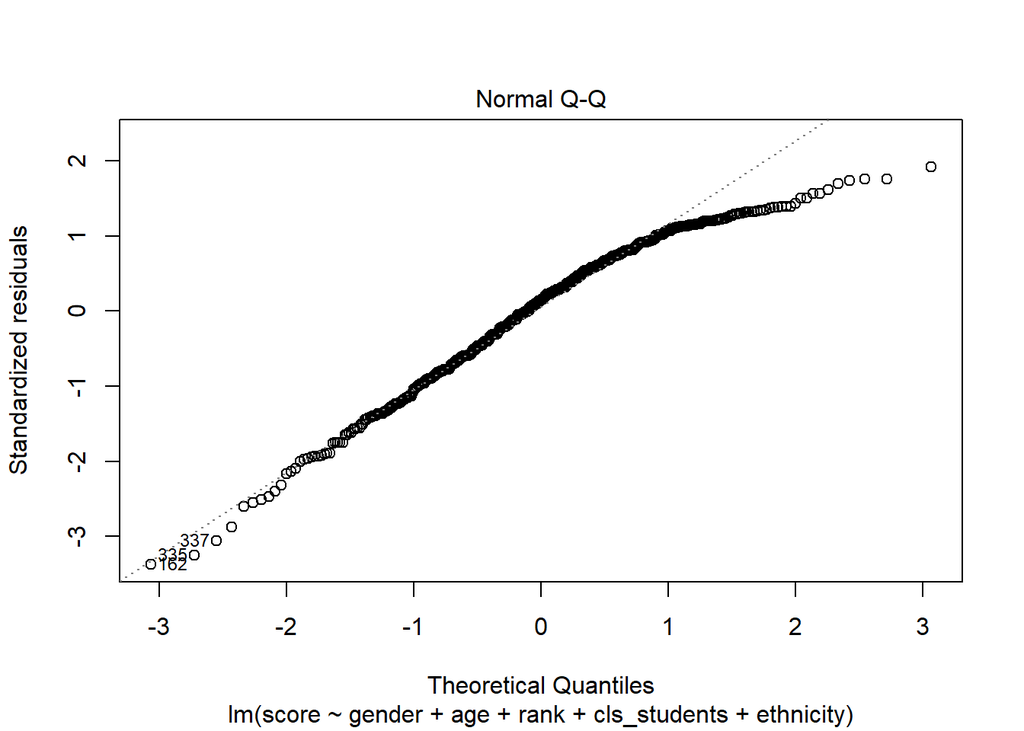

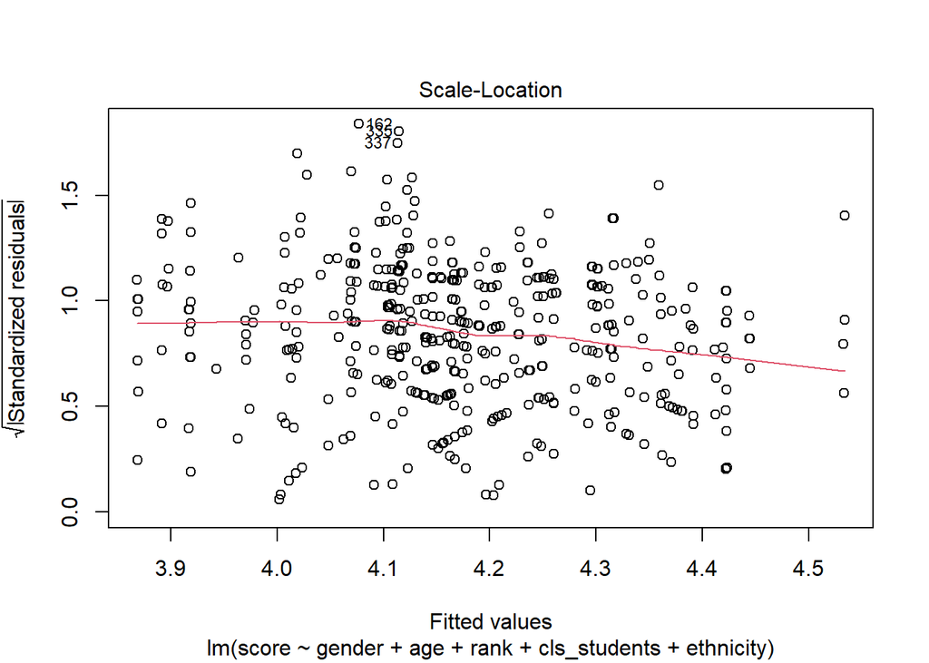

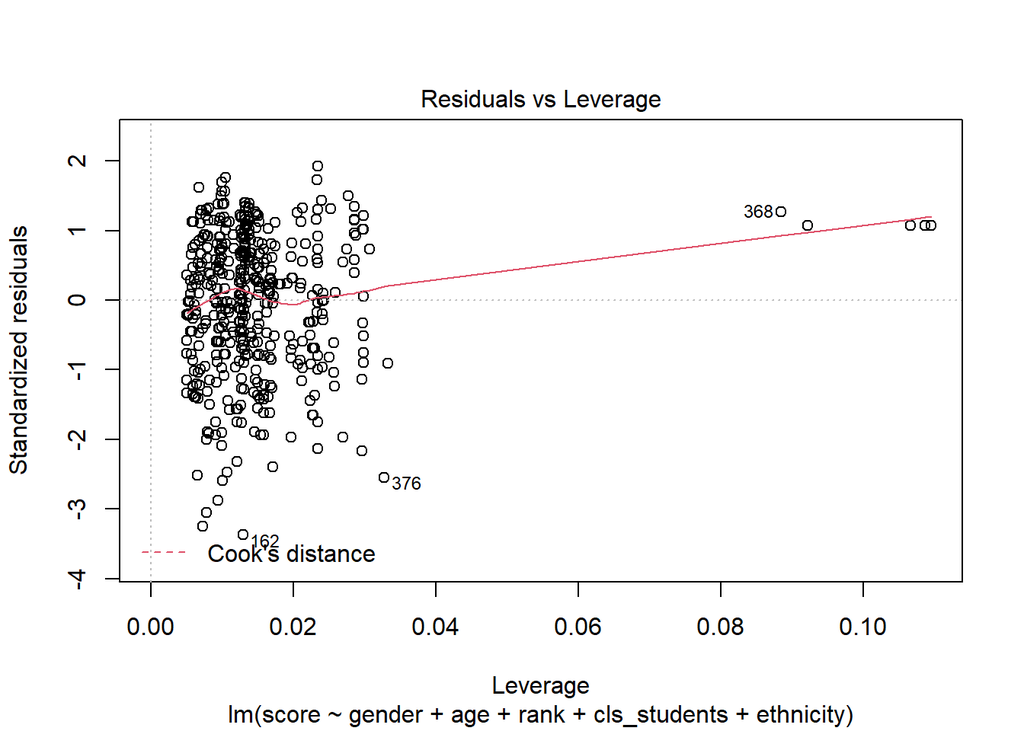

```r
plot(score_model)
```

### Transform Variables

**Quadratic Term**

I decided to create quadratic term for class students

```r
evals_disc12$cls_students_sq2 <- evals_disc12$cls_students^2
```

**Dichonomous by quatitative**

to create a dichotomous by quatitative variable. I will multiply age by a Dichotomous variable ‘num_students’

num_students was created earlier based on the scatterplot

```r
evals_disc12$cls_by_age <- evals_disc12$num_students_n * evals_disc12$age
```

### Second Model

**New Variables**

- cls_by_age
- num_students_n
- num_students

```r
score_model_t <- lm(score ~ cls_by_age + num_students + cls_students_sq2, data = evals_disc12)

summary(score_model_t)
```

```
##
## Call:
## lm(formula = score ~ cls_by_age + num_students + cls_students_sq2,
##     data = evals_disc12)
##
## Residuals:
##     Min      1Q  Median      3Q     Max
## -1.9245 -0.3462  0.1093  0.4183  0.8889
##
## Coefficients:
##                    Estimate Std. Error t value Pr(>|t|)
## (Intercept)       4.022e+00  8.643e-02  46.530   <2e-16 ***
## cls_by_age       -6.674e-03  2.777e-03  -2.403   0.0166 *
## num_studentsY     4.761e-01  1.612e-01   2.954   0.0033 **
## cls_students_sq2  2.205e-06  8.547e-07   2.580   0.0102 *
## ---
## Signif. codes:  0 '***' 0.001 '**' 0.01 '*' 0.05 '.' 0.1 ' ' 1
##
## Residual standard error: 0.5382 on 459 degrees of freedom
## Multiple R-squared:  0.02692,    Adjusted R-squared:  0.02056
## F-statistic: 4.232 on 3 and 459 DF,  p-value: 0.005752
```

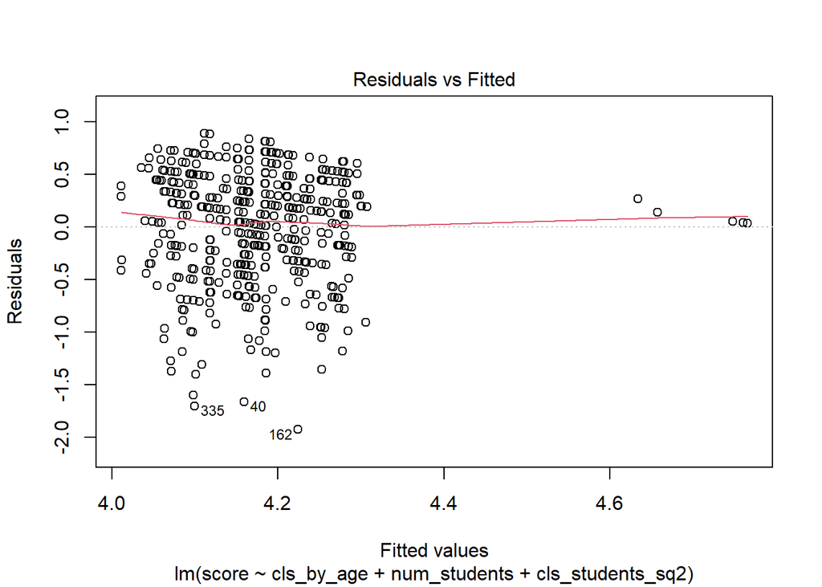

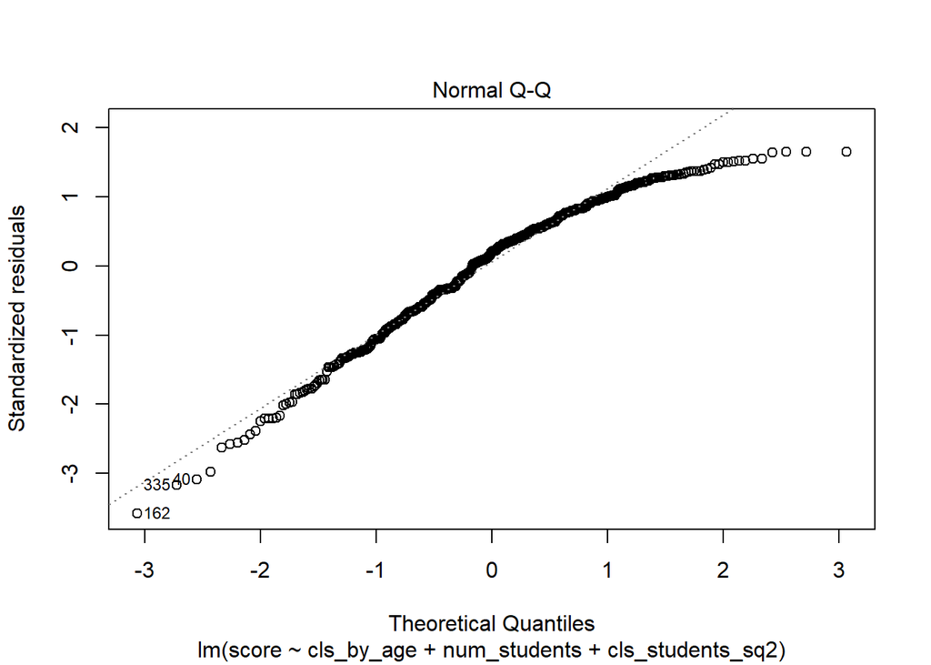

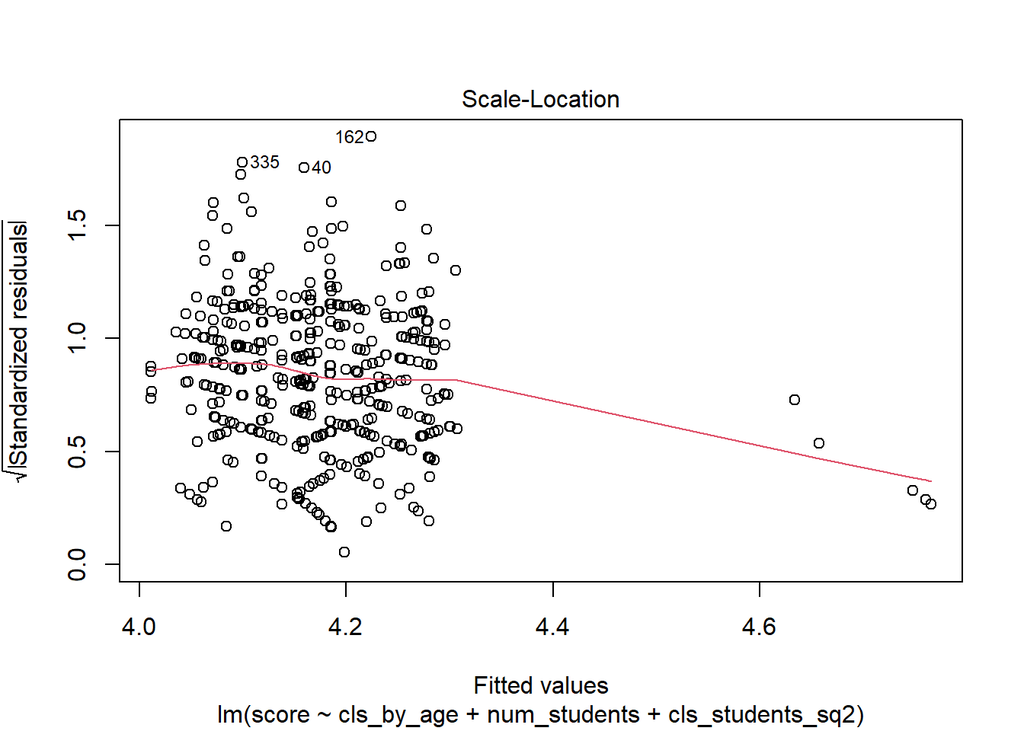

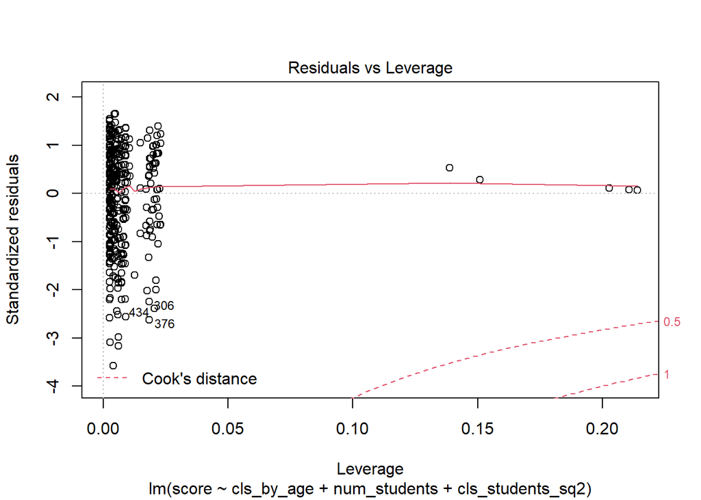

```r
plot(score_model_t)
```

## Conclusion

this model does not meet the level of the baseline model.